# Practical Machine Learning Project

Basudha Misra

September 12, 2017

## Introduction

A group of enthusiasts who take measurements to quantify how much of a particular activity they do using devices such as Jawbone Up, Nike FuelBand, and Fitbit about themselves regularly to improve their health, to find patterns in their behavior, or because they are tech geeks. But they rarely quantify how well they do it. In this project, our goal is to use data from accelerometers on the belt, forearm, arm, and dumbell of 6 participants. They were asked to perform barbell lifts correctly and incorrectly in 5 different ways. More information is available from the website here: http://groupware.les.inf.puc-rio.br/har (see the section on the Weight Lifting Exercise Dataset).

## Data Installation

The training data for this project are available here: https://d396qusza40orc.cloudfront.net/predmachlearn/pml-training.csv

The test data are available here: https://d396qusza40orc.cloudfront.net/predmachlearn/pml-testing.csv

The data for this project come from this source: http://groupware.les.inf.puc-rio.br/har.

```r
# locally data installing
training <- read.csv("pml-training.csv", na.strings = c("NA", ""))
testing <- read.csv("pml-testing.csv", na.strings = c("NA", ""))
dim(training)
```

```
## [1] 19622   160
```

```r
dim(testing)
```

```
## [1]  20 160
```

Here our aim is to predict the $classe$ variable from the training data.

## Data Cleaning

There are 100 variables in training data, each of which has 19216 missing values. On top of that first seven columns(variables) have no relevance in predicting $classe$ variable. This is why we remove these 107 columns from training and testing data.

```r
training <- training[, colSums(is.na(training)) == 0]
testing <- testing[, colSums(is.na(testing)) == 0]
training <- training[, -c(1:7)]
testing <- testing[, -c(1:7)]
```

## Data Splitting

First we install all the packages required for this project.

```r
library(caret); library(rattle); library(rpart); library(rpart.plot)
library(randomForest); library(repmis)
```

We divide our training data into training and validation purpose using a 60:40 ratio to compute the out of sample errors.

```r
set.seed(1234)
inTrain <- createDataPartition(training$classe, p = 0.6, list = FALSE)
train_p <- training[inTrain, ]
valid_p<- training[-inTrain, ]
```

## Prediction Models

We use two different type of models: Classification Tree and Random Forests to predict the outcome.

### Classification Tree

Here we consider 5-fold cross validation which is a pretty standard process to save computation time without affecting the prediction precision much.

```r
set.seed(1234)
cv_control <- trainControl(method = "cv", number = 5)
set.seed(1234)
rpart_fit <- train(classe ~ ., data = train_p, method = "rpart",
                   trControl = cv_control)
print(rpart_fit, digits = 4)
```

```
## CART
##
## 11776 samples
##    52 predictor
##     5 classes: 'A', 'B', 'C', 'D', 'E'
##
## No pre-processing
## Resampling: Cross-Validated (5 fold)
## Summary of sample sizes: 9422, 9421, 9420, 9420, 9421
## Resampling results across tuning parameters:
##
##   cp       Accuracy  Kappa
##   0.03619  0.5150    0.3708
##   0.06111  0.4173    0.2107
##   0.11652  0.3497    0.1000
##
## Accuracy was used to select the optimal model using  the largest value.
## The final value used for the model was cp = 0.03619.
```

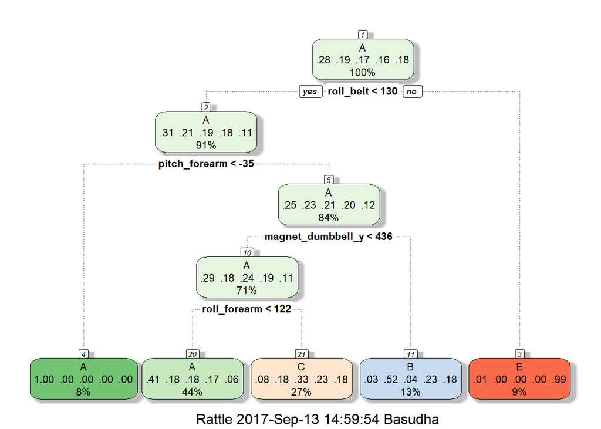

```r
fancyRpartPlot(rpart_fit$finalModel)
```

```r
# predicting outcomes using validation set
rpart_predict <- predict(rpart_fit, valid_p)

# Showing prediction result
rpart_confusion <- confusionMatrix(valid_p$classe, rpart_predict)
rpart_confusion
```

```
## Confusion Matrix and Statistics
##
##           Reference
## Prediction    A    B    C    D    E
##          A 2029   44  155    0    4
##          B  638  505  375    0    0
##          C  644   49  675    0    0
##          D  567  232  487    0    0
##          E  209  211  383    0  639
##
## Overall Statistics
##
##                Accuracy : 0.4904
##                  95% CI : (0.4793, 0.5016)
##     No Information Rate : 0.5209
##     P-Value [Acc > NIR] : 1
##
##                   Kappa : 0.3339
##  Mcnemar's Test P-Value : NA
##
## Statistics by Class:
##
##                      Class: A Class: B Class: C Class: D Class: E
## Sensitivity            0.4965  0.48511  0.32530       NA  0.99378
## Specificity            0.9460  0.85114  0.87992   0.8361  0.88852
## Pos Pred Value         0.9091  0.33267  0.49342       NA  0.44313
## Neg Pred Value         0.6334  0.91530  0.78388       NA  0.99938
## Prevalence             0.5209  0.13268  0.26447   0.0000  0.08195
## Detection Rate         0.2586  0.06436  0.08603   0.0000  0.08144
## Detection Prevalence   0.2845  0.19347  0.17436   0.1639  0.18379
## Balanced Accuracy      0.7212  0.66812  0.60261       NA  0.94115
```

```r
rpart_accuracy <- rpart_confusion$overall[1]
rpart_accuracy
```

```
## Accuracy
## 0.490441
```

We can see that the accuracy rate of Classification Tree model is only 49%, i.e. out of sample error is 51% which is not reliable. We need to explore other possibilities like Random Forests.

### Random Forests

We check whether Random Forests improve the accuracy or not.

```r
set.seed(1234)
rf_fit <- train(classe ~ ., data = train_p, method = "rf",
                   trControl = cv_control)
print(rf_fit, digits = 4)
```

```
## Random Forest
##
## 11776 samples
##    52 predictor
##     5 classes: 'A', 'B', 'C', 'D', 'E'
##
## No pre-processing
## Resampling: Cross-Validated (5 fold)
## Summary of sample sizes: 9422, 9421, 9420, 9420, 9421
## Resampling results across tuning parameters:
##
##   mtry  Accuracy  Kappa
##    2    0.9885    0.9855
##   27    0.9882    0.9851
##   52    0.9822    0.9774
##
## Accuracy was used to select the optimal model using  the largest value.
## The final value used for the model was mtry = 2.
```

```r
# predicting outcomes using validation set
rf_predict <- predict(rf_fit, valid_p)

# Showing prediction result
rf_confusion <- confusionMatrix(valid_p$classe, rf_predict)
rf_confusion
```

```
## Confusion Matrix and Statistics
##
##           Reference
## Prediction    A    B    C    D    E
##          A 2230    2    0    0    0
##          B   11 1502    5    0    0
##          C    0   12 1351    5    0
##          D    0    0   28 1256    2
##          E    0    0    3    2 1437
##
## Overall Statistics
##
##                Accuracy : 0.9911
##                  95% CI : (0.9887, 0.993)
##     No Information Rate : 0.2856
##     P-Value [Acc > NIR] : < 2.2e-16
##
##                   Kappa : 0.9887
##  Mcnemar's Test P-Value : NA
##
## Statistics by Class:
##
##                      Class: A Class: B Class: C Class: D Class: E
## Sensitivity            0.9951   0.9908   0.9740   0.9945   0.9986
## Specificity            0.9996   0.9975   0.9974   0.9954   0.9992
## Pos Pred Value         0.9991   0.9895   0.9876   0.9767   0.9965
## Neg Pred Value         0.9980   0.9978   0.9944   0.9989   0.9997
## Prevalence             0.2856   0.1932   0.1768   0.1610   0.1834
## Detection Rate         0.2842   0.1914   0.1722   0.1601   0.1832
## Detection Prevalence   0.2845   0.1935   0.1744   0.1639   0.1838
## Balanced Accuracy      0.9974   0.9941   0.9857   0.9950   0.9989
```

```r
rf_accuracy <- rf_confusion$overall[1]
rf_accuracy
```

```
##  Accuracy
## 0.9910783
```

The accuracy rate has sufficiently improved for Random Forests to 99.1% compared to only 49% from Classification tree. This means for Random Forests we have only 0.9% out of sample error which is reasonably acceptable.

## Testing set Prediction

Out of Classification tree and Random Forests we will use Random Forests to predict the testing set outcome variable $classe$ due to it’s much higher accuracy rate.

```r
prediction <- predict(rf_fit, testing)
prediction
```

```
##  [1] B A B A A E D B A A B C B A E E A B B B
## Levels: A B C D E
```